# Внешний курс 2 этап

Архитектура компьютеров и операционные системы

Венис Дмитрий

1032253513@rudn.ru

Российский университет дружбы народов

2026-05-03

# Информация

## Докладчик

- Венис Дмитрий
- студент НКАбд-01-25
- Российский университет дружбы народов им. П. Лумумбы
- 1032253513@rudn.ru
- https://github.com/VenisDmitry

# Цель работы

Целью работы является прохождение второго этапа внешнего курса «Введение в Linux» и закрепление практических навыков работы с удалёнными серверами, передачей файлов, справочной информацией о программах, управлением процессами, многопоточными приложениями и использованием `tmux`.

# Задание

Необходимо пройти задания второго этапа внешнего курса и подготовить отчёт по всем выполненным активностям. Для каждого тестового вопроса и практического задания требуется привести:

- скриншот с формулировкой задания;
- скриншот, подтверждающий успешное прохождение;
- краткое пояснение по выбору ответа или выполнению задания.

# Выполнение второго этапа

## Знакомство с сервером

Указал, что удалённый сервер можно использовать для хранения общедоступных и конфиденциальных данных, хранения больших объёмов информации, а также для выполнения сложных вычислений (Рисунок 1).

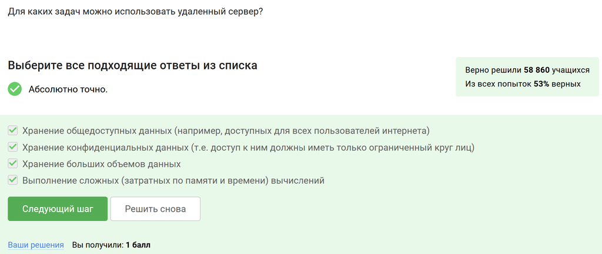

Рисунок 1: Задание о назначении удалённого сервера

В задании требовалось выбрать все подходящие варианты использования удалённого сервера. Были отмечены все перечисленные пункты, поскольку сервер действительно может применяться и для хранения данных, и для выполнения вычислительных задач.

Указал, что без опаски по интернету можно пересылать открытый ключ `id_rsa.pub` (Рисунок 2).

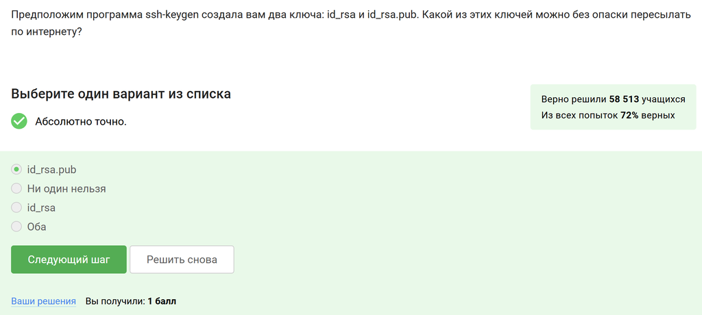

Рисунок 2: Выбор ключа, который можно пересылать по интернету

В задании нужно было определить, какой из ключей пары `ssh-keygen` можно передавать другим пользователям. Безопасно передавать именно открытый ключ `id_rsa.pub`, так как закрытый ключ `id_rsa` должен оставаться только у владельца.

## Обмен файлами

Указал, что для копирования каталога `stepic` на сервер вместе со всем содержимым и подкаталогами подходит команда `scp -r stepic username@server:~/` (Рисунок 3).

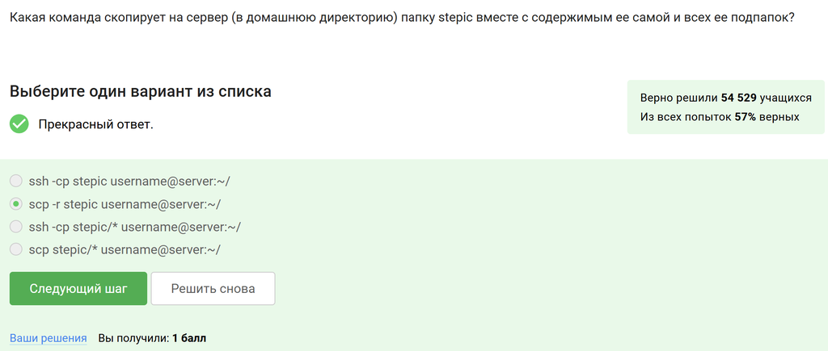

Рисунок 3: Выбор команды для копирования каталога на сервер

В этом задании требовалось выбрать корректную команду для рекурсивного копирования каталога на сервер. Подходит именно `scp -r`, поскольку ключ `-r` отвечает за передачу директории вместе со всеми вложенными файлами и папками.

Указал, что проблему при установке программы через `sudo apt-get install program` могут устранить проверка интернет-соединения, его настройка при отсутствии и команда `sudo apt-get update` (Рисунок 4).

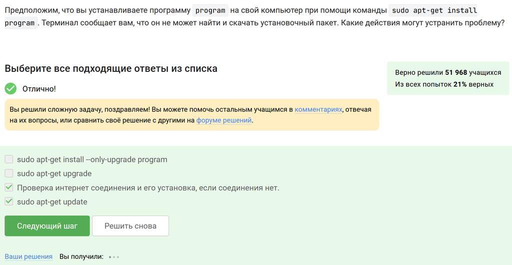

Рисунок 4: Выбор действий при проблеме с установкой пакета

Если пакет не удаётся найти или скачать, сначала нужно проверить наличие доступа к сети, затем при необходимости восстановить соединение и обновить сведения о пакетах при помощи `sudo apt-get update`. Именно эти действия и были выбраны.

Указал, что программу FileZilla можно использовать для просмотра содержимого каталогов на локальном компьютере и на сервере, а также для копирования файлов с сервера на компьютер (Рисунок 5).

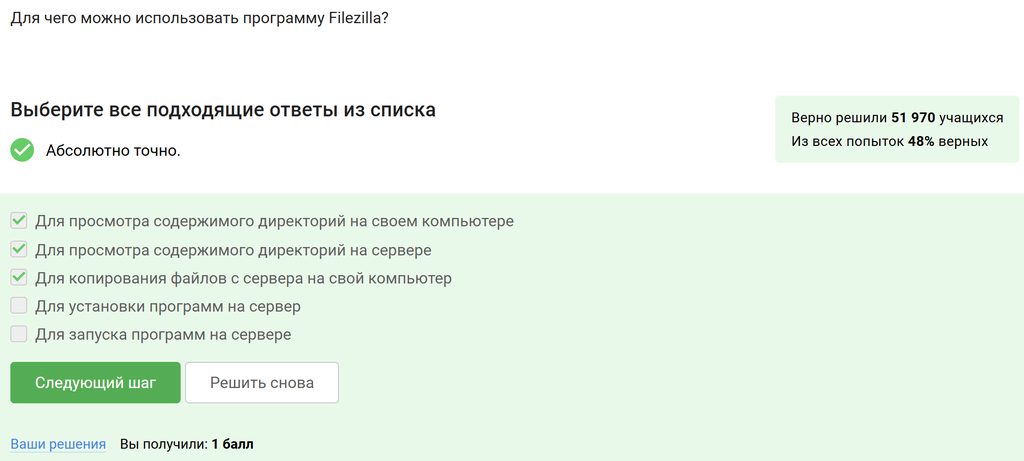

Рисунок 5: Выбор возможностей программы FileZilla

В задании требовалось отметить функции FileZilla. Эта программа действительно предназначена для работы с файлами и каталогами на локальной и удалённой стороне, а также для передачи файлов между ними.

## Запуск приложений

Указал, что при необходимости запуска на сервере программы, которой нужен экран, можно либо найти терминальную версию программы, либо настроить сервер на поддержку вывода графической информации (Рисунок 6).

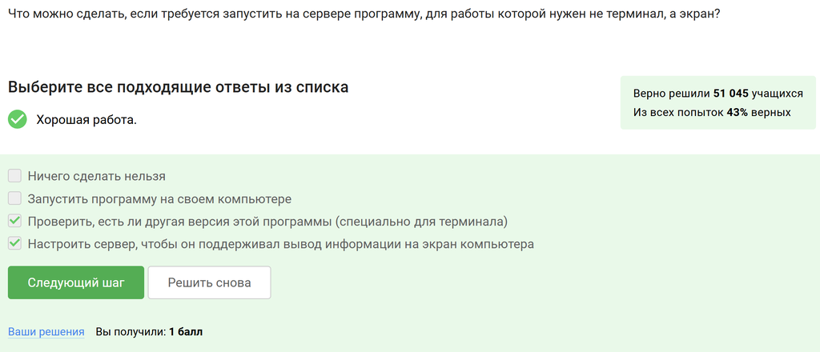

Рисунок 6: Выбор решений для запуска графической программы на сервере

В задании рассматривалась ситуация, когда программа требует графический интерфейс. Наиболее разумные варианты — использовать консольную версию приложения или настроить вывод графики с удалённого сервера.

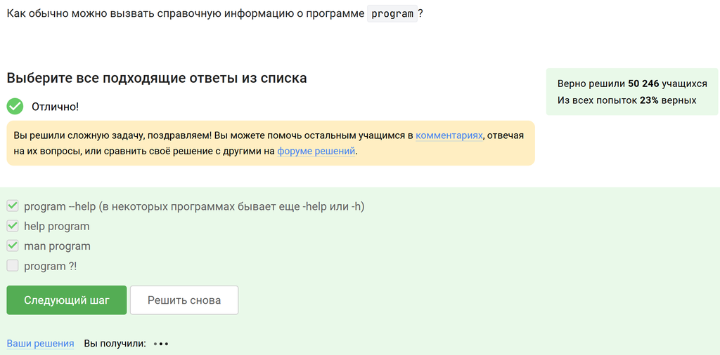

Рисунок 7: Выбор способов получения справки о программе

Изучил справку по программе FastQC и указал, что на вход она может принимать форматы `fastq`, `bam_mapped`, `sam_mapped`, `bam`, `sam` (Рисунок 8).

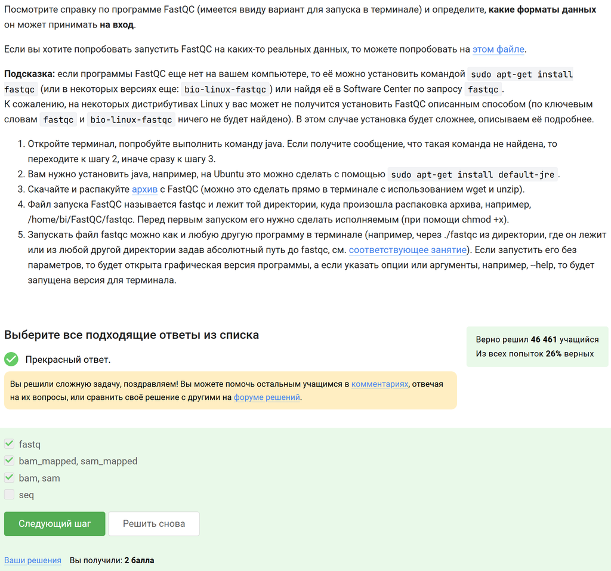

Рисунок 8: Определение форматов входных данных FastQC

В этом задании нужно было ознакомиться со справкой FastQC и определить поддерживаемые форматы данных. По результатам изучения были выбраны форматы, связанные с чтениями и выравниваниями, которые программа действительно умеет анализировать.

Изучил справку по ClustalW и ввёл команду `clustalw -align -infile=test.fasta` для выполнения множественного выравнивания файла `test.fasta` (Рисунок 9).

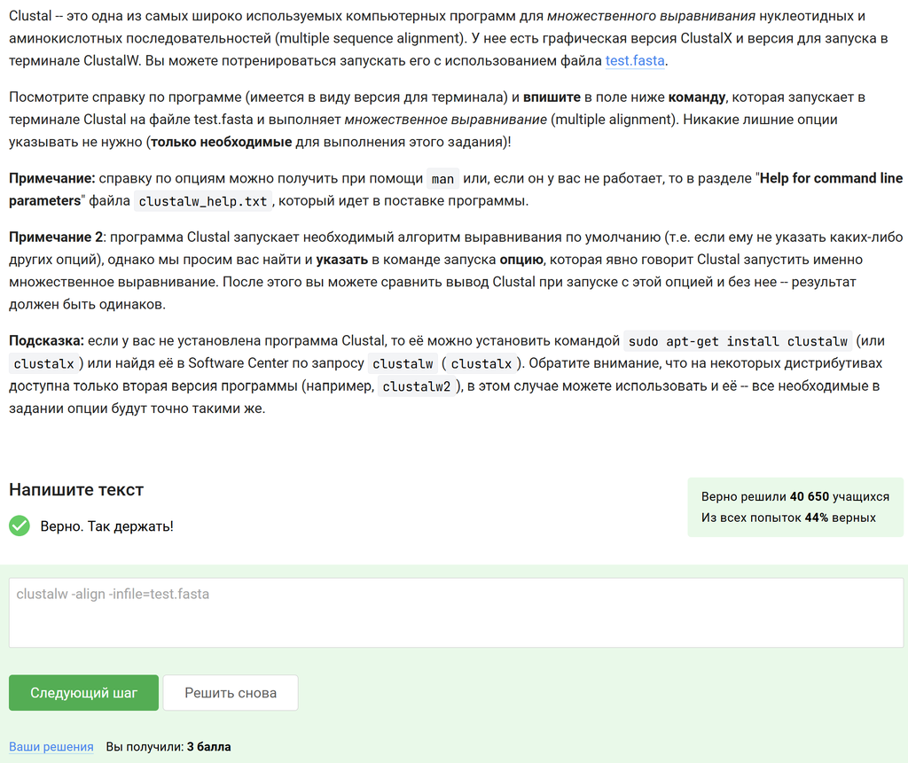

Рисунок 9: Ввод команды запуска ClustalW для множественного выравнивания

В задании требовалось не просто запустить программу, а указать минимально необходимую команду, которая явно задаёт выполнение множественного выравнивания. Для этого была использована опция `-align` и указан входной файл через `-infile`.

## Контроль запускаемых программ

Указал, что после последовательности действий `fg %1`, `Ctrl+C`, `fg %2`, `Ctrl+Z`, `jobs` информация будет показана только о программах `program2` и `program3` (Рисунок 10).

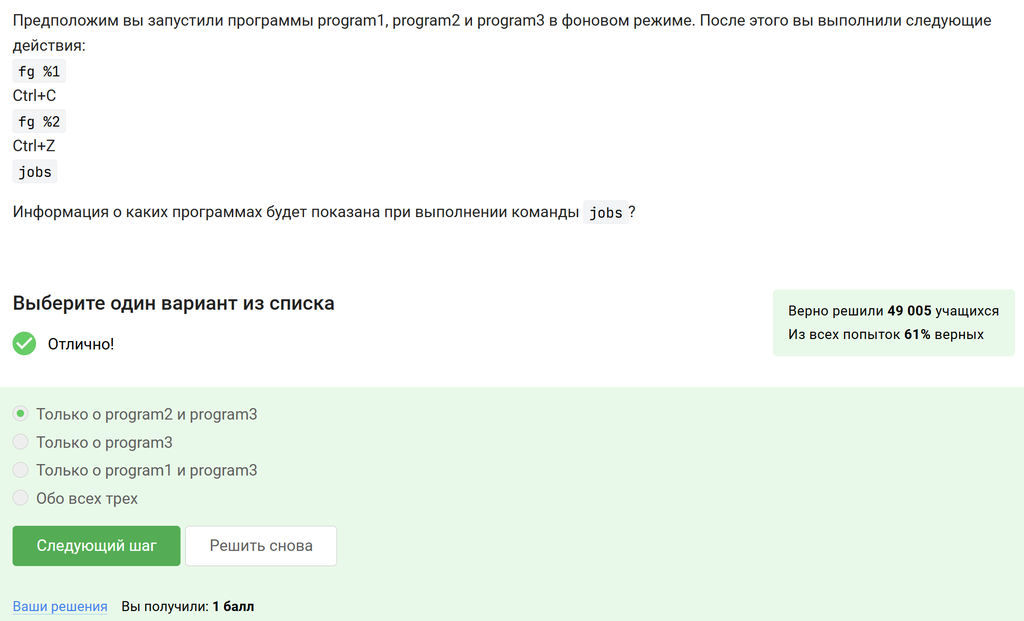

Рисунок 10: Выбор ответа о результате выполнения команд fg, Ctrl+C, Ctrl+Z и jobs

После `Ctrl+C` первая программа завершается и больше не относится к списку заданий оболочки. Вторая после `Ctrl+Z` оказывается приостановленной, а третья остаётся в фоне, поэтому команда `jobs` покажет только `program2` и `program3`.

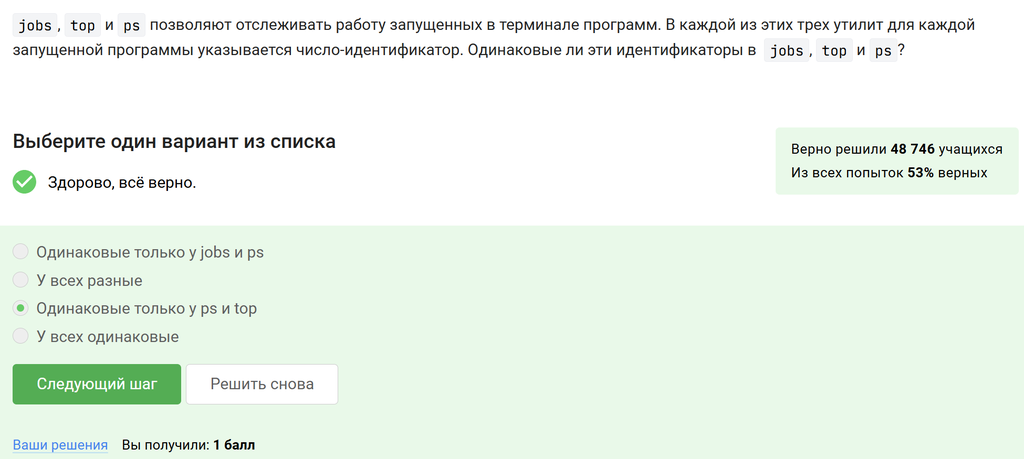

Рисунок 11: Выбор ответа о различии идентификаторов в jobs, top и ps

В задании сравнивались идентификаторы, которые показывают разные утилиты. `jobs` использует номера заданий оболочки, а `top` и `ps` работают с идентификаторами процессов, поэтому значения не совпадают.

Указал, что мгновенно завершить остановленный процесс можно командой `kill -9` (Рисунок 12).

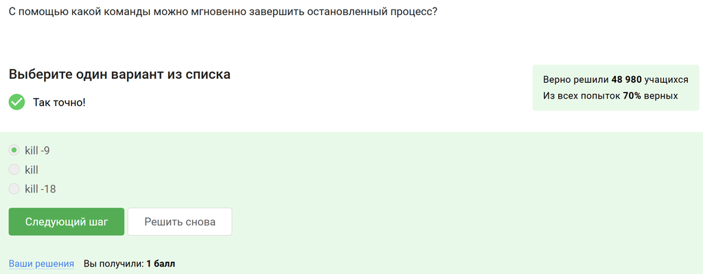

Рисунок 12: Выбор команды для немедленного завершения остановленного процесса

Сигнал `-9` соответствует принудительному завершению процесса. Поэтому именно этот вариант был выбран как правильный.

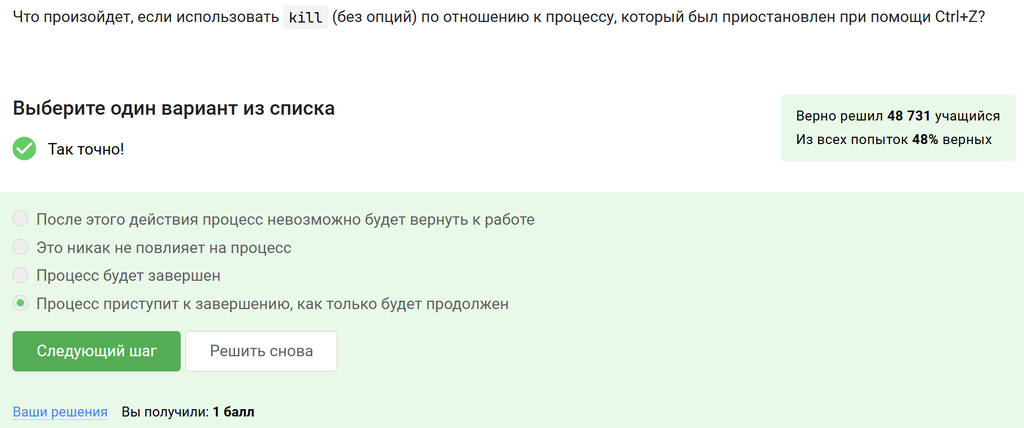

Рисунок 13: Выбор результата выполнения kill для остановленного процесса

## Многопоточные приложения

Указал, что остановленное по `Ctrl+Z` многопоточное приложение использует `0% CPU` (Рисунок 14).

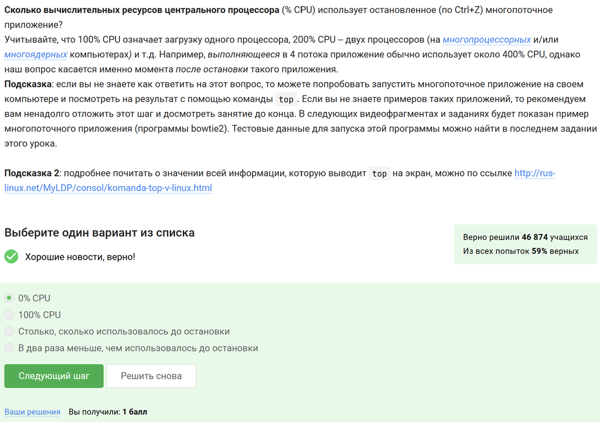

Рисунок 14: Выбор ответа о загрузке CPU остановленным приложением

После остановки процесса выполнение инструкций прекращается, поэтому процессорное время больше не расходуется. Именно поэтому был выбран ответ `0% CPU`.

Указал, что остановленное многопоточное приложение продолжает занимать столько памяти, сколько потребляло в момент остановки (Рисунок 15).

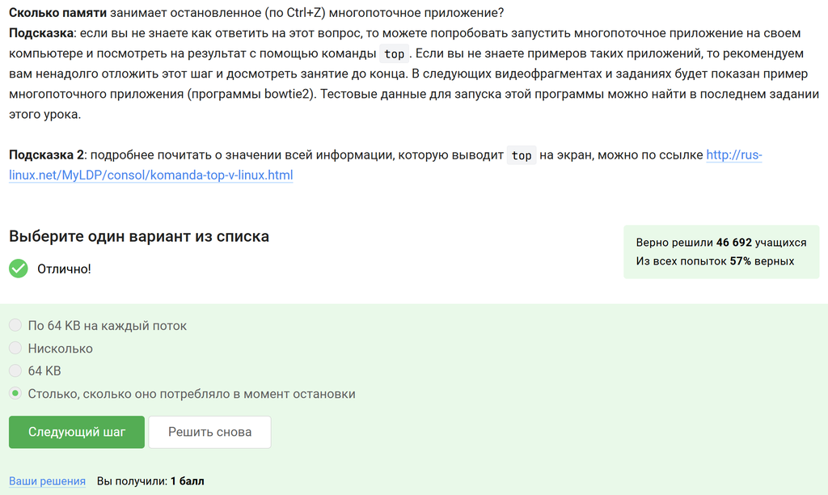

Рисунок 15: Выбор ответа о памяти остановленного приложения

Остановка процесса не освобождает уже занятую память автоматически. Пока процесс не завершён, его адресное пространство сохраняется, поэтому объём памяти остаётся тем же.

Указал, что принудительно завершить один отдельный поток запущенного многопоточного приложения нельзя (Рисунок 16).

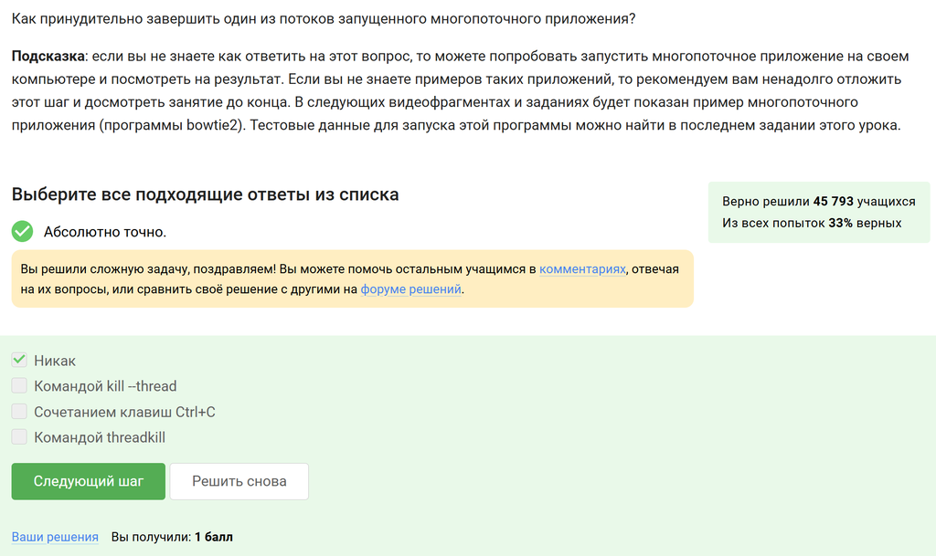

Рисунок 16: Выбор ответа о завершении одного потока многопоточного приложения

В задании рассматривалась обычная работа из командной строки Linux. Стандартными средствами вроде `kill` управляют процессом целиком, а не отдельным потоком, поэтому был выбран вариант «Никак».

Изучил справку по `bowtie2` и определил, что в несколько потоков можно выполнять только второй этап, то есть запуск `bowtie2`, а не `bowtie2-build` (Рисунок 17).

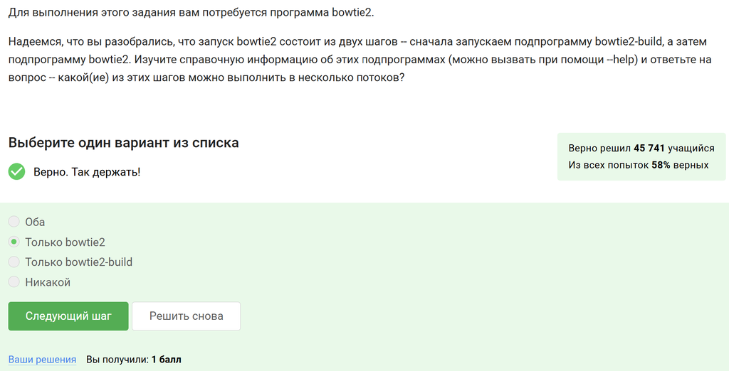

Рисунок 17: Выбор этапа bowtie2, который можно выполнять в несколько потоков

В этом задании нужно было посмотреть параметры двух подпроцессов и определить, где доступна многопоточность. Поддержка нескольких потоков есть именно у `bowtie2`.

Выполнил практическое задание с `bowtie2`: запустил второй этап программы, перенаправил поток ошибок в файл `align.err` и проверил его содержимое в терминале.

После выполнения задания загрузил полученный файл `align.err` на платформу, что было принято системой как верное решение (Рисунок 18).

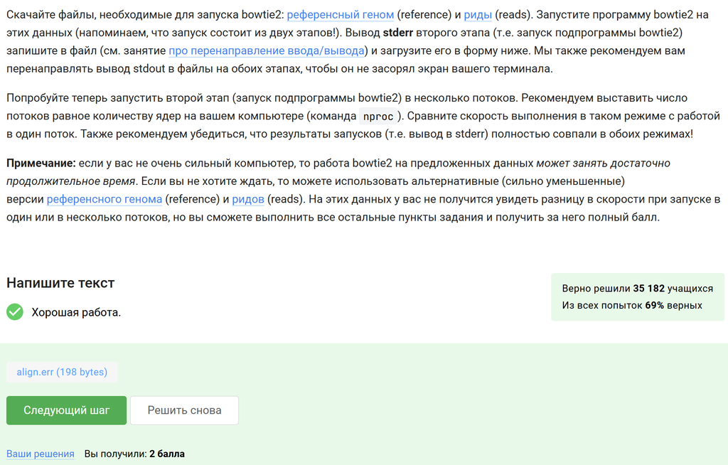

Рисунок 18: Загрузка файла align.err на платформу

В задании требовалось не только получить файл с выводом ошибок, но и загрузить его в форму проверки. Файл был успешно прикреплён и зачтён.

## Менеджер терминалов tmux

Указал, что если открыть две вкладки терминала, остановить процесс в одной из них, перейти во вторую и выполнить `fg`, терминал сообщит, что нет процесса для запуска в `fg` (Рисунок 19).

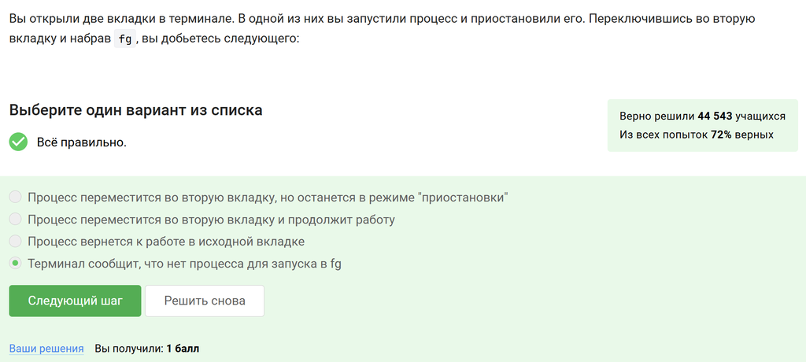

Рисунок 19: Выбор ответа о команде fg в другой вкладке терминала

Команда `fg` работает только с заданиями текущей оболочки. Во второй вкладке это задание не существует, поэтому оболочка сообщает об отсутствии процесса для перевода на передний план.

Указал, что если в `tmux` осталась последняя открытая вкладка и в ней выполнить команду `exit`, то `tmux` завершит работу (Рисунок 20).

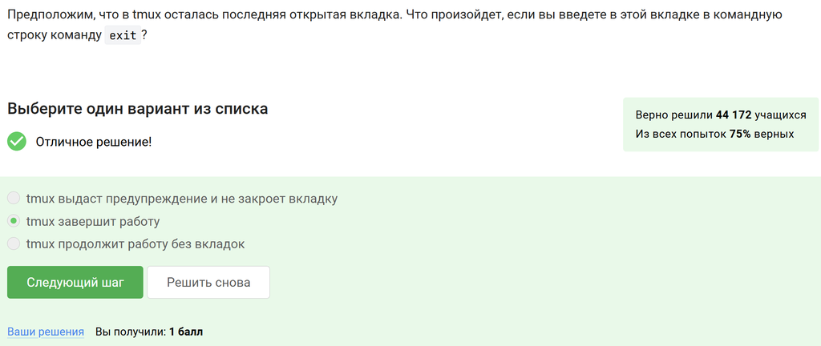

Рисунок 20: Выбор ответа о завершении tmux при exit в последней вкладке

Когда закрывается последняя активная вкладка или окно, завершается и сама сессия `tmux`. Поэтому был выбран именно этот вариант.

Указал, что если запустить `tmux` на сервере и затем закрыть локальный терминал, соединение с сервером прервётся, но работа `tmux` продолжится (Рисунок 21).

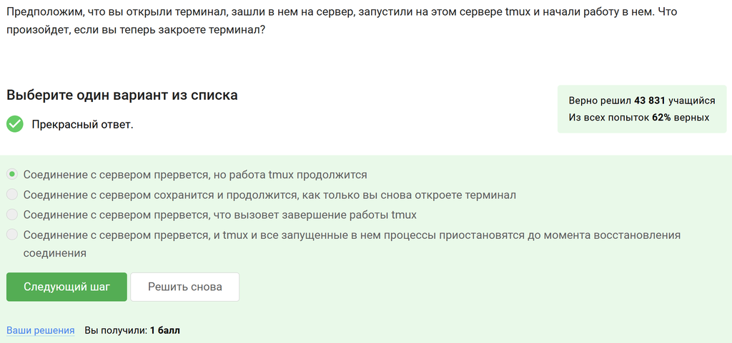

Рисунок 21: Выбор ответа о поведении tmux после закрытия терминала

Смысл `tmux` как раз в том, что сессия продолжает существовать на удалённой машине независимо от текущего подключения пользователя. После нового входа к ней можно снова присоединиться.

Указал, что если запустить процесс в фоновом режиме во вкладке `tmux`, а затем принудительно закрыть эту вкладку, то вкладка закроется вместе с запущенным в ней процессом (Рисунок 22).

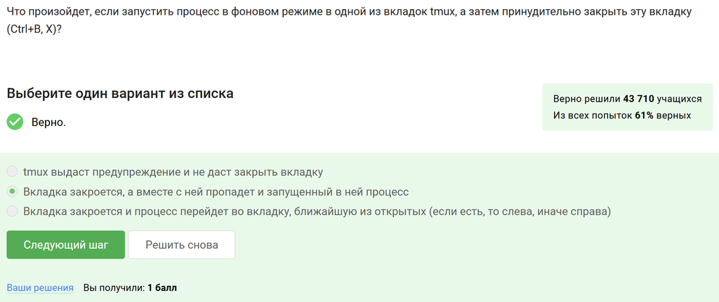

Рисунок 22: Выбор ответа о закрытии вкладки tmux с фоновым процессом

В задании рассматривалось закрытие окна `tmux`. При закрытии окна завершаются и связанные с ним процессы, если для них не был предусмотрен иной способ продолжения работы.

Изучил команды `tmux` и указал, что за переименование текущей вкладки отвечает сочетание `Ctrl+B`, затем `,` (Рисунок 23).

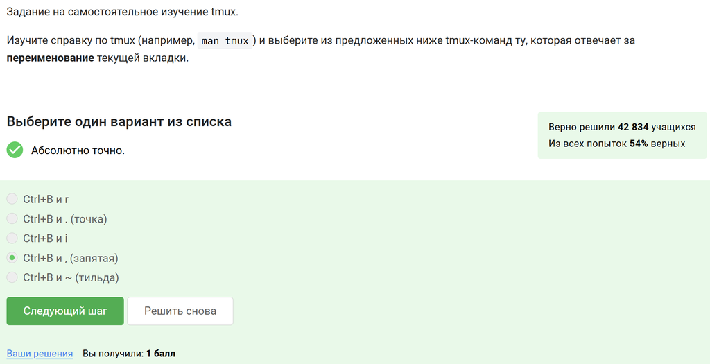

Рисунок 23: Выбор команды tmux для переименования вкладки

Это стандартное сочетание клавиш в `tmux` для изменения имени текущего окна, поэтому был выбран вариант с запятой.

При самостоятельном изучении возможностей `tmux` отметил верные утверждения о разделении вкладок: можно закрывать одну из частей комбинацией `Ctrl+B`, затем `x`; можно делить окно несколько раз; команды разделения действуют только в текущей вкладке; при дополнительном вертикальном делении уже разделённой горизонтально вкладки получается три области (Рисунок 24).

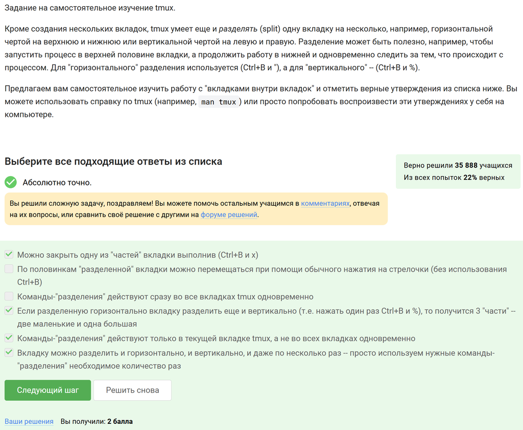

Рисунок 24: Самостоятельное задание по разделению окон в tmux

В этом задании нужно было самостоятельно проверить работу разделения окон в `tmux`. По результатам были отмечены утверждения, соответствующие фактическому поведению программы при разбиении и закрытии панелей.

# Выводы

В ходе выполнения второго этапа внешнего курса были изучены и закреплены навыки работы с удалёнными серверами, SSH-ключами, передачей файлов, получением справочной информации о программах, управлением процессами и использованием `tmux`. Также были рассмотрены особенности многопоточных приложений и выполнено практическое задание с программой `bowtie2`, включающее перенаправление потоков вывода и загрузку результата на платформу. Полученные знания позволяют увереннее работать в Linux-среде как локально, так и на удалённых серверах.